# Memory

# 1 Description of DataSchema variable

The description of harmonised variable is the following:

- Short name: `memory`
- Variable label: `Difficulties with memory`
- Variable description: `Difficulties with memory`
- Domain: `Health status and functional limitations`
- Value type: `categorical`
- Category coding:

| **Code** | **Category Label** |
| --- | --- |
| 0 | Presence of difficulties with memory |
| 1 | Absence of memory difficulties |

- Category missings:

| **Code** | **Category Label** |
| --- | --- |
| 991 | CAPI/interviewer error |
| 992 | Impute |
| 993 | Disable to measure |
| 994 | Not attempt/not done |
| 995 | Does not answer |
| 996 | Not applicable |
| 997 | Refuse |
| 998 | Do not know |
| 999 | Missing |

# 2 Data process

## 2.1 England

### 2.1.1 Wave 1

#### 2.1.1.1 Study-specific variable description

| **Name** | `cfmetm` |
| --- | --- |
| **Label** | `Self-reported memory - How would you rate your memory at the present time?` |
| **Table name** | `wave_1_core_data_v3` |
| **Categories** | `1 = Excellent; 2 = Very good; 3 = Good; 4 = Fair; 5 = or, poor?` |
| **Missings** | `-9 = Refusal; -8 = Don't Know; -1 = Not applicable` |
| **Description** |  |

cfmetm

| Sample size | Missing values |
| --- | --- |
| 12099 | 329 |

Category

|  | 1 | 2 | 3 | 4 | 5 |
| --- | --- | --- | --- | --- | --- |
| Frequency | 635.00 | 2557.00 | 4807.00 | 3010.00 | 761.00 |
| Percentage | 5.25 | 21.13 | 39.73 | 24.88 | 6.29 |

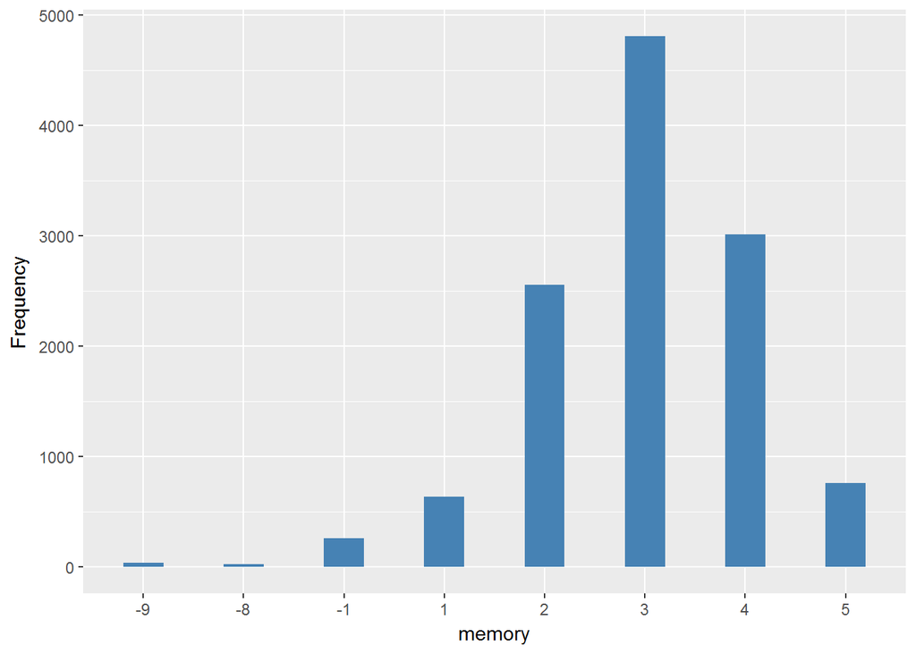

#### 2.1.1.2 Harmonisation algorithm

To compute the harmonize variable from the study-specific variable it has to be recoded as follows:

- `1 Excellent into 1`
- `2 Very good into 1`
- `3 Good into 1`
- `4 Fair into 0`
- `5 or, poor? into 0`
- `-9 Refusal into 997`
- `-8 Don't know into 998`
- `-1 Not applicable into 996`

**R script:**

```r
ELSA_ds_w1 <- tibble(id = ELSA_w1_memory$id)
ELSA_ds_w1$memory <- car::recode(ELSA_w1_memory$cfmetm, "1 = '1';2 = '1';3 = '1';4 = '0';5 = '0';-9 = '997';-8 = '998';-1 = '996' ")
ELSA_ds_w1$memory <- labelled(ELSA_ds_w1$memory, labels = c(Presence = 0, Absence = 1,
    Missing = 999, Do_not_know = 998, Refuse = 997, Not_applicable = 996, Does_not_answer = 995,
    Not_attempt_not_done = 994, Disable_to_measure = 993, Impute = 992, CAPI_interviewer_error = 991))
```

#### 2.1.1.3 Statistical description of the new harmonised variable

memory

| Sample size | Missing values |
| --- | --- |
| 12099 | 329 |

Category

|  | 0 | 1 |
| --- | --- | --- |
| Frequency | 3771.00 | 7999.00 |
| Percentage | 31.17 | 66.11 |

Type of missing

|  | 991 | 992 | 993 | 994 | 995 | 996 | 997 | 998 | 999 | NA |
| --- | --- | --- | --- | --- | --- | --- | --- | --- | --- | --- |
| Frequency | 0 | 0 | 0 | 0 | 0 | 263.00 | 39.00 | 27.00 | 0 | 0 |
| Percentage | 0 | 0 | 0 | 0 | 0 | 2.17 | 0.32 | 0.22 | 0 | 0 |

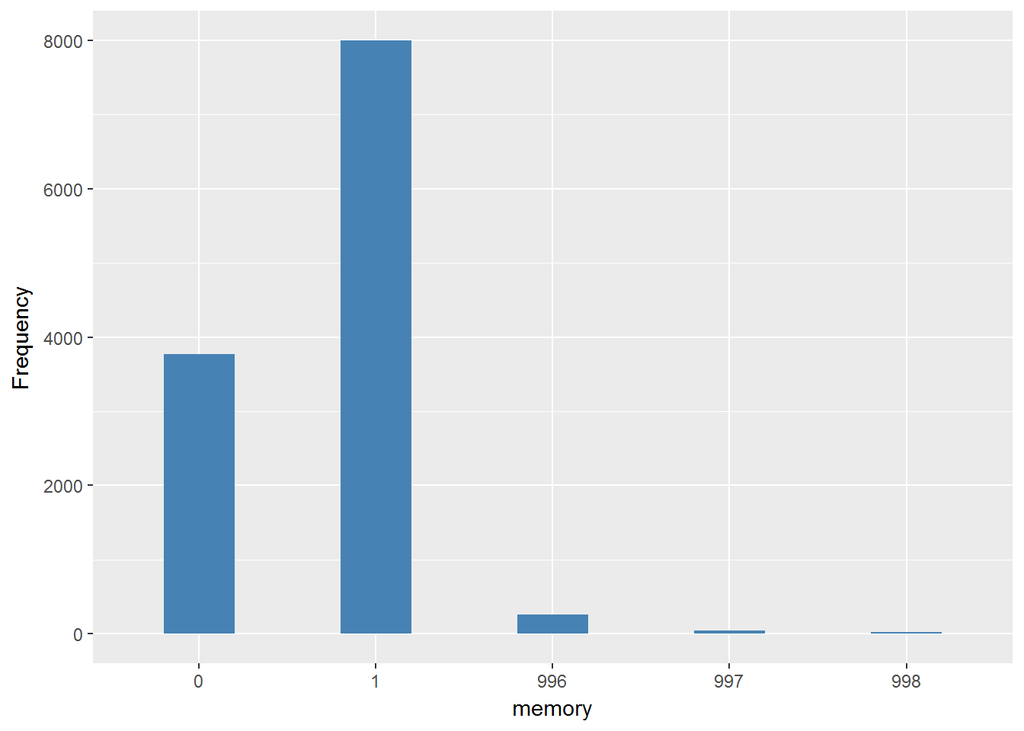

#### 2.1.1.4 Validation

|  | 5,4->0 | 3,2,1->1 | -1->996 | -9->997 | -8->998 |
| --- | --- | --- | --- | --- | --- |
| BeforeH | 3771 | 7999 | 263 | 39 | 27 |
| AfterH | 3771 | 7999 | 263 | 39 | 27 |

### 2.1.2 Wave 2

#### 2.1.2.1 Study-specific variable description

| **Name** | `CfMetM` |
| --- | --- |
| **Label** | `Self-reported memory - How would you rate your memory at the present time?` |
| **Table name** | `wave_2_core_data_v4` |
| **Categories** | `1 = Excellent; 2 = Very good; 3 = Good; 4 = Fair; 5 = or, poor?` |
| **Missings** | `-9 = Refusal; -8 = Don't Know; -1 = Not applicable` |
| **Description** |  |

CfMetM

| Sample size | Missing values |
| --- | --- |
| 9432 | 186 |

Category

|  | 1 | 2 | 3 | 4 | 5 |
| --- | --- | --- | --- | --- | --- |
| Frequency | 315.00 | 1735.00 | 3966.00 | 2596.00 | 634.00 |
| Percentage | 3.34 | 18.39 | 42.05 | 27.52 | 6.72 |

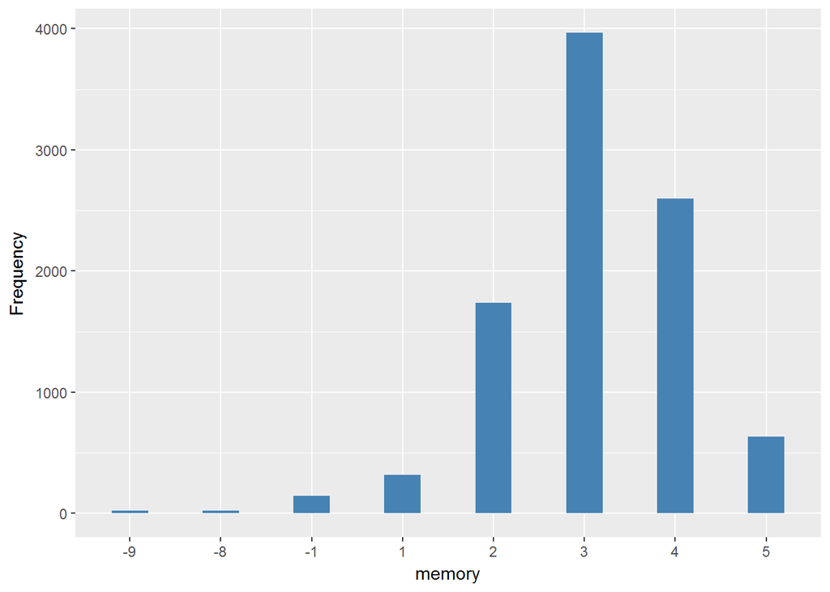

#### 2.1.2.2 Harmonisation algorithm

To compute the harmonize variable from the study-specific variable it has to be recoded as follows:

- `1 Excellent into 1`
- `2 Very good into 1`
- `3 Good into 1`
- `4 Fair into 0`
- `5 or, poor? into 0`
- `-9 Refusal into 997`
- `-8 Don't know into 998`
- `-1 Not applicable into 996`

**R script:**

```r
ELSA_ds_w2 <- tibble(id = ELSA_w2_memory$id)
ELSA_ds_w2$memory <- car::recode(ELSA_w2_memory$CfMetM, "1 = '1';2 = '1';3 = '1';4 = '0';5 = '0';-9 = '997';-8 = '998';-1 = '996' ")
ELSA_ds_w2$memory <- labelled(ELSA_ds_w2$memory, labels = c(Presence = 0, Absence = 1,
    Missing = 999, Do_not_know = 998, Refuse = 997, Not_applicable = 996, Does_not_answer = 995,
    Not_attempt_not_done = 994, Disable_to_measure = 993, Impute = 992, CAPI_interviewer_error = 991))
```

#### 2.1.2.3 Statistical description of the new harmonised variable

memory

| Sample size | Missing values |
| --- | --- |
| 9432 | 186 |

Category

|  | 0 | 1 |
| --- | --- | --- |
| Frequency | 3230.00 | 6016.00 |
| Percentage | 34.25 | 63.78 |

Type of missing

|  | 991 | 992 | 993 | 994 | 995 | 996 | 997 | 998 | 999 | NA |
| --- | --- | --- | --- | --- | --- | --- | --- | --- | --- | --- |
| Frequency | 0 | 0 | 0 | 0 | 0 | 143.00 | 20.00 | 23.00 | 0 | 0 |
| Percentage | 0 | 0 | 0 | 0 | 0 | 1.52 | 0.21 | 0.24 | 0 | 0 |

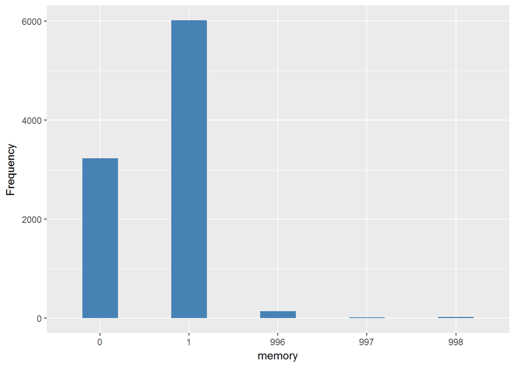

#### 2.1.2.4 Validation

|  | 5,4->0 | 3,2,1->1 | -1->996 | -9->997 | -8->998 |
| --- | --- | --- | --- | --- | --- |
| BeforeH | 3230 | 6016 | 143 | 20 | 23 |
| AfterH | 3230 | 6016 | 143 | 20 | 23 |

### 2.1.3 Wave 3

#### 2.1.3.1 Study-specific variable description

| **Name** | `cfmetm` |
| --- | --- |
| **Label** | `Self-reported memory - How would you rate your memory at the present time?` |
| **Table name** | `wave_3_elsa_data_v4` |
| **Categories** | `1 = Excellent; 2 = Very good; 3 = Good; 4 = Fair; 5 = or, poor?` |
| **Missings** | `-9 = Refusal; -8 = Don't Know; -1 = Not applicable` |
| **Description** |  |

cfmetm

| Sample size | Missing values |
| --- | --- |
| 9771 | 291 |

Category

|  | 1 | 2 | 3 | 4 | 5 |
| --- | --- | --- | --- | --- | --- |
| Frequency | 301.00 | 1623.00 | 4015.00 | 2801.00 | 740.00 |
| Percentage | 3.08 | 16.61 | 41.09 | 28.67 | 7.57 |

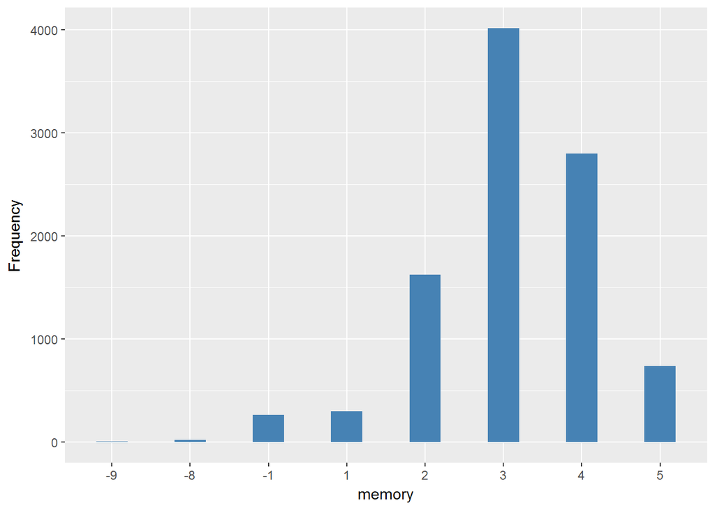

#### 2.1.3.2 Harmonisation algorithm

**R script:**

```r
ELSA_ds_w3 <- tibble(id = ELSA_w3_memory$id)
ELSA_ds_w3$memory <- car::recode(ELSA_w3_memory$cfmetm, "1 = '1';2 = '1';3 = '1';4 = '0';5 = '0';-9 = '997';-8 = '998';-1 = '996' ")
ELSA_ds_w3$memory <- labelled(ELSA_ds_w3$memory, labels = c(Presence = 0, Absence = 1,
    Missing = 999, Do_not_know = 998, Refuse = 997, Not_applicable = 996, Does_not_answer = 995,
    Not_attempt_not_done = 994, Disable_to_measure = 993, Impute = 992, CAPI_interviewer_error = 991))
```

#### 2.1.3.3 Statistical description of the new harmonised variable

memory

| Sample size | Missing values |
| --- | --- |
| 9771 | 291 |

Category

|  | 0 | 1 |
| --- | --- | --- |
| Frequency | 3541.00 | 5939.00 |
| Percentage | 36.24 | 60.78 |

Type of missing

|  | 991 | 992 | 993 | 994 | 995 | 996 | 997 | 998 | 999 | NA |
| --- | --- | --- | --- | --- | --- | --- | --- | --- | --- | --- |
| Frequency | 0 | 0 | 0 | 0 | 0 | 263.00 | 8.00 | 20.0 | 0 | 0 |
| Percentage | 0 | 0 | 0 | 0 | 0 | 2.69 | 0.08 | 0.2 | 0 | 0 |

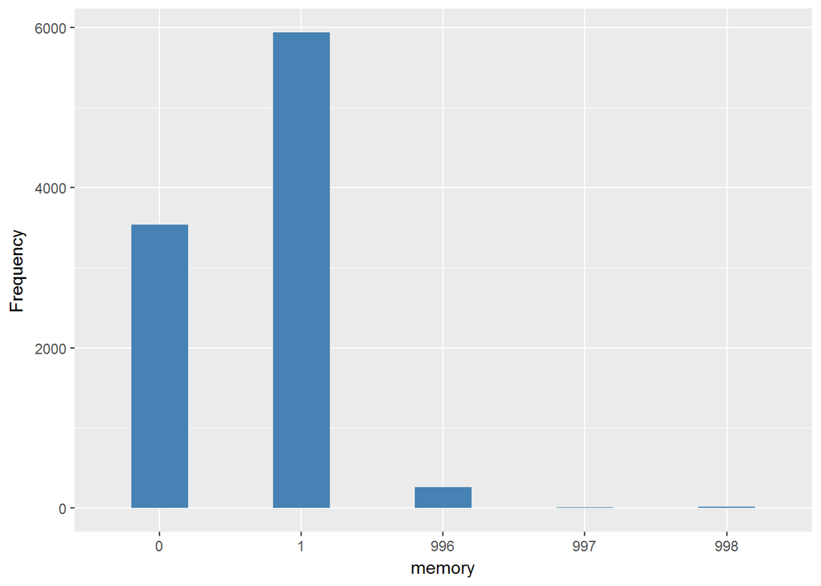

#### 2.1.3.4 Validation

|  | 5,4->0 | 3,2,1->1 | -1->996 | -9->997 | -8->998 |
| --- | --- | --- | --- | --- | --- |
| BeforeH | 3541 | 5939 | 263 | 8 | 20 |
| AfterH | 3541 | 5939 | 263 | 8 | 20 |

### 2.1.4 Wave 4

#### 2.1.4.1 Study-specific variable description

| **Name** | `cfmetm` |
| --- | --- |
| **Label** | `Self-reported memory - How would you rate your memory at the present time?` |
| **Table name** | `wave_4_elsa_data_v3` |
| **Categories** | `1 = Excellent; 2 = Very good; 3 = Good; 4 = Fair; 5 = or, poor?` |
| **Missings** | `-9 = Refusal; -8 = Don't Know; -1 = Not applicable` |
| **Description** |  |

cfmetm

| Sample size | Missing values |
| --- | --- |
| 11050 | 503 |

Category

|  | 1 | 2 | 3 | 4 | 5 |
| --- | --- | --- | --- | --- | --- |
| Frequency | 382.00 | 1959.00 | 4463.00 | 2966.00 | 777.00 |
| Percentage | 3.46 | 17.73 | 40.39 | 26.84 | 7.03 |

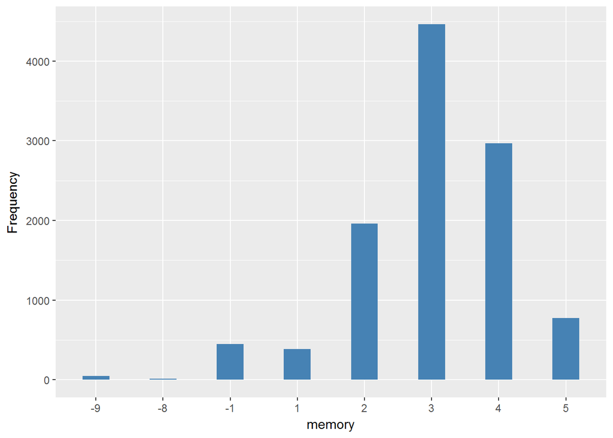

#### 2.1.4.2 Harmonisation algorithm

To compute the harmonize variable from the study-specific variable it has to be recoded as follows:

- `1 Excellent into 1`
- `2 Very good into 1`
- `3 Good into 1`
- `4 Fair into 0`
- `5 or, poor? into 0`
- `-9 Refusal into 997`
- `-8 Don't know into 998`
- `-1 Not applicable into 996`

**R script:**

```r
ELSA_ds_w4 <- tibble(id = ELSA_w4_memory$id)
ELSA_ds_w4$memory <- car::recode(ELSA_w4_memory$cfmetm, "1 = '1';2 = '1';3 = '1';4 = '0';5 = '0';-9 = '997';-8 = '998';-1 = '996' ")
ELSA_ds_w4$memory <- labelled(ELSA_ds_w4$memory, labels = c(Presence = 0, Absence = 1,
    Missing = 999, Do_not_know = 998, Refuse = 997, Not_applicable = 996, Does_not_answer = 995,
    Not_attempt_not_done = 994, Disable_to_measure = 993, Impute = 992, CAPI_interviewer_error = 991))
```

#### 2.1.4.3 Statistical description of the new harmonised variable

memory

| Sample size | Missing values |
| --- | --- |
| 11050 | 503 |

Category

|  | 0 | 1 |
| --- | --- | --- |
| Frequency | 3743.00 | 6804.00 |
| Percentage | 33.87 | 61.57 |

Type of missing

|  | 991 | 992 | 993 | 994 | 995 | 996 | 997 | 998 | 999 | NA |
| --- | --- | --- | --- | --- | --- | --- | --- | --- | --- | --- |
| Frequency | 0 | 0 | 0 | 0 | 0 | 446.00 | 44.0 | 13.00 | 0 | 0 |
| Percentage | 0 | 0 | 0 | 0 | 0 | 4.04 | 0.4 | 0.12 | 0 | 0 |

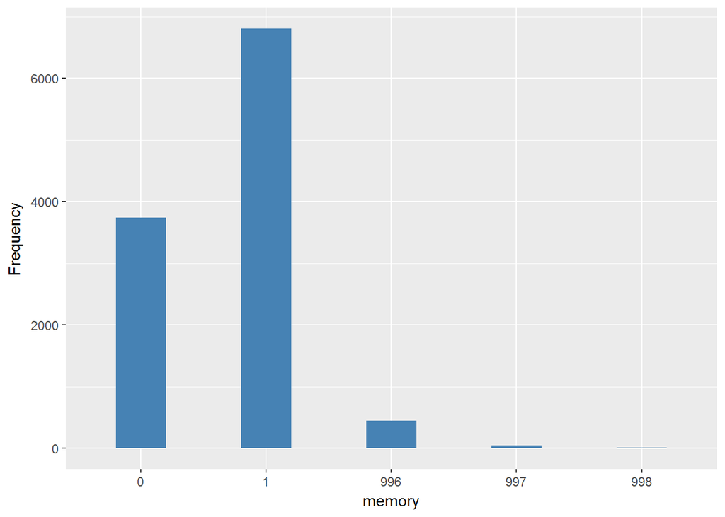

#### 2.1.4.4 Validation

|  | 5,4->0 | 3,2,1->1 | -1->996 | -9->997 | -8->998 |
| --- | --- | --- | --- | --- | --- |
| BeforeH | 3743 | 6804 | 446 | 44 | 13 |
| AfterH | 3743 | 6804 | 446 | 44 | 13 |

### 2.1.5 Wave 5

Not found.

### 2.1.6 Wave 6

Not found.

### 2.1.7 Wave 7

#### 2.1.7.1 Study-specific variable description

| **Name** | `CfMetM` |
| --- | --- |
| **Label** | `Self-reported memory - How would you rate your memory at the present time?` |
| **Table name** | `wave_7_elsa_data` |
| **Categories** | `1 = Excellent; 2 = Very good; 3 = Good; 4 = Fair; 5 = or, poor?` |
| **Missings** | `-9 = Refusal; -8 = Don't Know; -1 = Not applicable` |
| **Description** |  |

CfMetM

| Sample size | Missing values |
| --- | --- |
| 9666 | 658 |

Category

|  | 1 | 2 | 3 | 4 | 5 |
| --- | --- | --- | --- | --- | --- |
| Frequency | 321.00 | 1564.00 | 4000.00 | 2452.00 | 671.00 |
| Percentage | 3.32 | 16.18 | 41.38 | 25.37 | 6.94 |

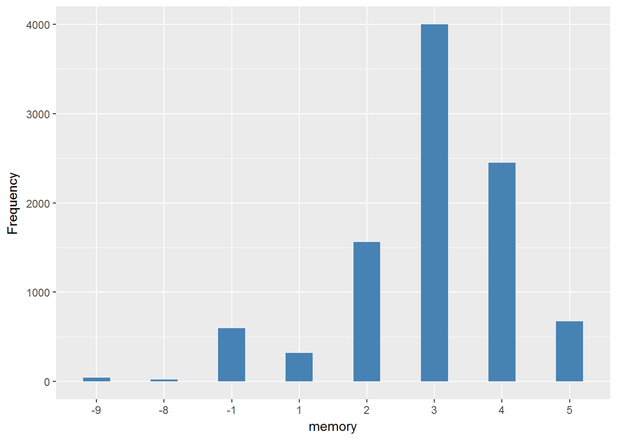

#### 2.1.7.2 Harmonisation algorithm

To compute the harmonize variable from the study-specific variable it has to be recoded as follows:

- `1 Excellent into 1`
- `2 Very good into 1`
- `3 Good into 1`
- `4 Fair into 0`
- `5 or, poor? into 0`
- `-9 Refusal into 997`
- `-8 Don't know into 998`
- `-1 Not applicable into 996`

**R script:**

```r
ELSA_ds_w7 <- tibble(id = ELSA_w7_memory$id)
ELSA_ds_w7$memory <- car::recode(ELSA_w7_memory$CfMetM, "1 = '1';2 = '1';3 = '1';4 = '0';5 = '0';-9 = '997';-8 = '998';-1 = '996' ")
ELSA_ds_w7$memory <- labelled(ELSA_ds_w7$memory, labels = c(Presence = 0, Absence = 1,
    Missing = 999, Do_not_know = 998, Refuse = 997, Not_applicable = 996, Does_not_answer = 995,
    Not_attempt_not_done = 994, Disable_to_measure = 993, Impute = 992, CAPI_interviewer_error = 991))
```

#### 2.1.7.3 Statistical description of the new harmonised variable

memory

| Sample size | Missing values |
| --- | --- |
| 9666 | 658 |

Category

|  | 0 | 1 |
| --- | --- | --- |
| Frequency | 3123.00 | 5885.00 |
| Percentage | 32.31 | 60.88 |

Type of missing

|  | 991 | 992 | 993 | 994 | 995 | 996 | 997 | 998 | 999 | NA |
| --- | --- | --- | --- | --- | --- | --- | --- | --- | --- | --- |
| Frequency | 0 | 0 | 0 | 0 | 0 | 597.00 | 42.00 | 19.0 | 0 | 0 |
| Percentage | 0 | 0 | 0 | 0 | 0 | 6.18 | 0.43 | 0.2 | 0 | 0 |

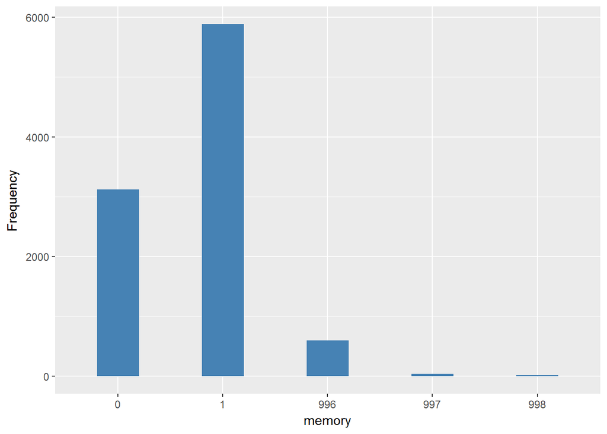

#### 2.1.7.4 Validation

|  | 5,4->0 | 3,2,1->1 | -1->996 | -9->997 | -8->998 |
| --- | --- | --- | --- | --- | --- |
| BeforeH | 3123 | 5885 | 597 | 42 | 19 |
| AfterH | 3123 | 5885 | 597 | 42 | 19 |

## 2.2 Summary of descriptive statistics of the harmonised variable accross populations and waves

Two tables are generated:

1. Percentages of categories in each harmonised variable.
2. Frequencies and percentages of individuals with different trajectories. To avoid too large table, Only trajectories with percentages larger than 0.3 are shown.

**R script:**

```r
ELSA_ds_w1$memory <- labelled(ELSA_ds_w1$memory, labels = c(Presence = 0, Absence = 1,
    Missing = 999, Do_not_know = 998, Refuse = 997, Not_applicable = 996, Does_not_answer = 995,
    Not_attempt_not_done = 994, Disable_to_measure = 993, Impute = 992, CAPI_interviewer_error = 991))
ELSA_ds_w2$memory <- labelled(ELSA_ds_w2$memory, labels = c(Presence = 0, Absence = 1,
    Missing = 999, Do_not_know = 998, Refuse = 997, Not_applicable = 996, Does_not_answer = 995,
    Not_attempt_not_done = 994, Disable_to_measure = 993, Impute = 992, CAPI_interviewer_error = 991))
ELSA_ds_w3$memory <- labelled(ELSA_ds_w3$memory, labels = c(Presence = 0, Absence = 1,
    Missing = 999, Do_not_know = 998, Refuse = 997, Not_applicable = 996, Does_not_answer = 995,
    Not_attempt_not_done = 994, Disable_to_measure = 993, Impute = 992, CAPI_interviewer_error = 991))
ELSA_ds_w4$memory <- labelled(ELSA_ds_w4$memory, labels = c(Presence = 0, Absence = 1,
    Missing = 999, Do_not_know = 998, Refuse = 997, Not_applicable = 996, Does_not_answer = 995,
    Not_attempt_not_done = 994, Disable_to_measure = 993, Impute = 992, CAPI_interviewer_error = 991))
ELSA_ds_w7$memory <- labelled(ELSA_ds_w7$memory, labels = c(Presence = 0, Absence = 1,
    Missing = 999, Do_not_know = 998, Refuse = 997, Not_applicable = 996, Does_not_answer = 995,
    Not_attempt_not_done = 994, Disable_to_measure = 993, Impute = 992, CAPI_interviewer_error = 991))

tt <- frq(ELSA_ds_w1$memory)[[1]][, c(1:2, 4)]
tt[4] <- frq(ELSA_ds_w2$memory)[[1]][, c(4)]
tt[5] <- frq(ELSA_ds_w3$memory)[[1]][, c(4)]
tt[6] <- frq(ELSA_ds_w4$memory)[[1]][, c(4)]
tt[7] <- frq(ELSA_ds_w7$memory)[[1]][, c(4)]
tt[13, ] <- c("n", "sample size", length(ELSA_ds_w1$memory), length(ELSA_ds_w2$memory),
    length(ELSA_ds_w3$memory), length(ELSA_ds_w4$memory), length(ELSA_ds_w7$memory))
names(tt) <- c("val", "label", "w1", "w2", "w3", "w4", "w7")
kable(tt)
```

| val | label | w1 | w2 | w3 | w4 | w7 |
| --- | --- | --- | --- | --- | --- | --- |
| 0 | Presence | 31.17 | 34.25 | 36.24 | 33.87 | 32.31 |
| 1 | Absence | 66.11 | 63.78 | 60.78 | 61.57 | 60.88 |
| 991 | CAPI_interviewer_error | 0 | 0 | 0 | 0 | 0 |
| 992 | Impute | 0 | 0 | 0 | 0 | 0 |
| 993 | Disable_to_measure | 0 | 0 | 0 | 0 | 0 |
| 994 | Not_attempt_not_done | 0 | 0 | 0 | 0 | 0 |
| 995 | Does_not_answer | 0 | 0 | 0 | 0 | 0 |
| 996 | Not_applicable | 2.17 | 1.52 | 2.69 | 4.04 | 6.18 |
| 997 | Refuse | 0.32 | 0.21 | 0.08 | 0.4 | 0.43 |
| 998 | Do_not_know | 0.22 | 0.24 | 0.2 | 0.12 | 0.2 |
| 999 | Missing | 0 | 0 | 0 | 0 | 0 |
| NA | NA | 0 | 0 | 0 | 0 | 0 |
| n | sample size | 12099 | 9432 | 9771 | 11050 | 9666 |

```r
dbb <- merge(ELSA_m_ds_w1, ELSA_m_ds_w2, by = "id", suffixes = c(".w1", ".w2"),
    all = T)
dbb <- merge(dbb, ELSA_m_ds_w3, by = "id", all = T)
dbb <- merge(dbb, ELSA_m_ds_w4, by = "id", suffixes = c(".w3", ".w4"), all = T)
dbb <- merge(dbb, ELSA_m_ds_w7, by = "id", all = T)
names(dbb) <- c("id", "w1", "w2", "w3", "w4", "w7")
v.dbb <- paste(dbb[, 2], dbb[, 3], dbb[, 4], dbb[, 5], dbb[, 6], sep = "")
f.dbb <- frq(v.dbb)[[1]][, c(1, 2, 4)]
kable(f.dbb[f.dbb[, 3] >= 0.3, ])
```

|  | val | frq | raw.prc |
| --- | --- | --- | --- |
| 1 | 00000 | 446 | 2.45 |
| 2 | 00001 | 100 | 0.55 |
| 3 | 0000NA | 260 | 1.43 |
| 9 | 000NANA | 237 | 1.30 |
| 10 | 00100 | 55 | 0.30 |
| 26 | 00NANANA | 307 | 1.69 |
| 27 | 01000 | 74 | 0.41 |
| 29 | 0100NA | 63 | 0.35 |
| 35 | 010NANA | 68 | 0.37 |
| 40 | 01111 | 133 | 0.73 |
| 41 | 0111NA | 55 | 0.30 |
| 44 | 011NANA | 60 | 0.33 |
| 53 | 01NANANA | 146 | 0.80 |
| 78 | 0NANANANA | 807 | 4.44 |
| 79 | 10000 | 135 | 0.74 |
| 80 | 10001 | 63 | 0.35 |
| 81 | 1000NA | 121 | 0.67 |
| 83 | 10011 | 57 | 0.31 |
| 87 | 100NANA | 113 | 0.62 |
| 88 | 10100 | 54 | 0.30 |
| 89 | 10101 | 54 | 0.30 |
| 92 | 10111 | 103 | 0.57 |
| 93 | 1011NA | 74 | 0.41 |
| 96 | 101NANA | 72 | 0.40 |
| 105 | 10NANANA | 227 | 1.25 |
| 106 | 11000 | 104 | 0.57 |
| 107 | 11001 | 64 | 0.35 |
| 108 | 1100NA | 120 | 0.66 |
| 109 | 11010 | 77 | 0.42 |
| 110 | 11011 | 148 | 0.81 |
| 111 | 1101NA | 85 | 0.47 |
| 114 | 110NANA | 118 | 0.65 |
| 115 | 11100 | 108 | 0.59 |
| 116 | 11101 | 156 | 0.86 |
| 117 | 1110NA | 160 | 0.88 |
| 118 | 11110 | 252 | 1.39 |
| 119 | 11111 | 1576 | 8.67 |
| 120 | 1111NA | 614 | 3.38 |
| 122 | 111NA1 | 59 | 0.32 |
| 123 | 111NANA | 406 | 2.23 |
| 132 | 11NANANA | 711 | 3.91 |
| 158 | 1NANANANA | 1340 | 7.38 |
| 191 | NANA000 | 122 | 0.67 |
| 192 | NANA001 | 56 | 0.31 |
| 193 | NANA00NA | 57 | 0.31 |
| 195 | NANA011 | 59 | 0.32 |
| 199 | NANA0NANA | 117 | 0.64 |
| 203 | NANA110 | 76 | 0.42 |
| 204 | NANA111 | 427 | 2.35 |
| 205 | NANA11NA | 207 | 1.14 |
| 208 | NANA1NANA | 284 | 1.56 |
| 209 | NANANA00 | 268 | 1.48 |
| 210 | NANANA01 | 157 | 0.86 |
| 211 | NANANA0NA | 248 | 1.36 |
| 212 | NANANA10 | 296 | 1.63 |
| 213 | NANANA11 | 978 | 5.38 |
| 214 | NANANA1NA | 610 | 3.36 |
| 215 | NANANANA0 | 370 | 2.04 |
| 216 | NANANANA1 | 1042 | 5.74 |
| 217 | NANANANANA | 579 | 3.19 |

# 3 Quality estimation

No comments (maybe category 4=0: self reported memory: fair=difficulties with memory could be revised… not sure whether it shout be recodified as 1= no difficulties).